# peloton_analysis

## Peloton Workout Visual Analysis

### An analysis and visual representation of Bryan and Hillary's Peloton workout data

### By: Bryan Kolano, June 28th, 2023

#### Background

As I was beginning this project to create the ETL pipeline, my wife suggested I do some analysis on her Peloton workouts. We don't take Peloton classes each day, but she said she was curious about anything interesting I could find in her data. She wanted to see which instructors made her work the hardest and how her output has changed over time. Additionally, she was curious to see how many classes she had taken around the time when first got the bike (October, 2021) as opposed to more recently.

For each piece of analysis, I did the same for my workout stats.

#### 1. Read in packages and data

```python
import pandas as pd
import matplotlib.pyplot as plt
import matplotlib.dates as mdates
import numpy as np
import seaborn as sns
import datetime

import psycopg2

#Need dotenv_values to easily read in environment variables
from dotenv import dotenv_values
```

The code chunk below makes a connection to the Postgres relational database hosted in AWS Relational Database Service (RDS).

```python
database = 'peloton'
user = 'postgres'
port = 5432
host = 'peloton-db.clki5gemvlvh.us-east-1.rds.amazonaws.com'

#grab environmental variable for postgres password
password_config = dotenv_values("/home/bryankolano/peloton_flow/.env")
password = password_config['POSTGRES_PASS']

#make connection to database with psycopg2
conn = psycopg2.connect(host=host, port=port,
                        database=database, user=user, password=password)

cursor = conn.cursor()

# Can use a simple SQL statement to grab all the data.  Since there are only
# ~700 observations, doing a SELECT * is no issue.
cursor.execute("SELECT * from Peloton;")

#Grab all the data.  Returns a list of tuples
data = cursor.fetchall()

cursor.close()
```

```python
#turn the response data into a pandas dataframe
df = pd.DataFrame(data, columns= ['workout_id', 'datetime', 'class_title', 'instructor', 'class_type',
                                'length_min', 'total_output_kj','rider_name'])

df.head()
```

|  | workout_id | datetime | class_title | instructor | class_type | length_min | total_output_kj | rider_name |
| --- | --- | --- | --- | --- | --- | --- | --- | --- |
| 0 | be33ccd69b584b1f941a0188cd4b4e22 | 2023-05-09 10:50:22 | 20 min Yoga Flow | Chelsea Jackson Roberts | yoga | 20 | 0.0 | Bryan Kolano |
| 1 | 704aca7bca3348c0a93c31ba70df7163 | 2023-05-09 09:32:08 | 30 min HIIT & Hills Ride | Sam Yo | cycling | 30 | 262.8 | Bryan Kolano |
| 2 | 02ccd6a0c4654addab6ca7b25749cfae | 2023-05-07 20:52:38 | 20 min Yoga Flow | Denis Morton | yoga | 20 | 0.0 | Bryan Kolano |
| 3 | e6ff3b849a754a07bee16ea9fcb004e3 | 2023-05-07 10:06:05 | 20 min HIIT Ride | Tunde Oyeneyin | cycling | 20 | 178.9 | Bryan Kolano |
| 4 | ab87345776424b88a6bff65665382a41 | 2023-05-04 10:34:17 | 30 min Yoga Flow | Kristin McGee | yoga | 30 | 0.0 | Bryan Kolano |

After reading in the data, there are some minor transformations needed to prep the data for analysis.

```python
#When I created the pipeline, I used date for the date of the class, but it's actually
# a datetime, so it is now renamed accordingly
df = df.rename(columns = {'date':'datetime'})

#set datetime column to datetime object
df['datetime'] = pd.to_datetime(df['datetime'])

#create month column that is periodicity of one month in the dataset
df['month'] = df['datetime'].dt.to_period('M')

# The previous line turned the month into a period object, but that can be difficult to graph.
# When plotting period objects, there is a lot of lost functionality.
# Therefore, if we change it to a datetime object,
#we can have more functionality when plotting
df['month'] = df['month'].dt.to_timestamp()
#grab the date from the datetime column
df['day'] = df['datetime'].dt.date
```

#### 2. General analysis

Some of the initial analysis I performed was on the classes we have taken in general. In the plot below, I've noticed a couple interesting things.

First, both Hillary and I had our first major spikes of classes in January, 2022. This is easily explainable because 2022 was going to be our first full year with the bike, so we wanted to get a jump on the annual challenge Peloton does each year. My spike is exceptionally high, because we have a friend who does some type of Peloton activity for an hour most days. I made it my goal to compete with her! I dedicated a lot of time in January to take multiple Peloton classes a day to beat our friend.

In february, I became busier at work and also had to deal with a hamstring issue, so I really had to cut the classes down (so needless to say, I lost the competition with our friend).

The second thing I notice is how much I fluctuate in my classes per month, where Hillary is more consistent than I am. I spend some time doing Peloton, but the majority of my exercise takes place at the gym. Hillary does the majority of her exercise on the Peloton. Her Peloton workout schedule, in general, is more consistent than mine, except for early summer of 2022 when she was about to give birth to our third daughter and had to cut her exercise load a lot. The amount of Peloton classes I take vary greatly, and usually depends on weather, injuries, and the extra itch to go ride the bike or do yoga on random occasion.

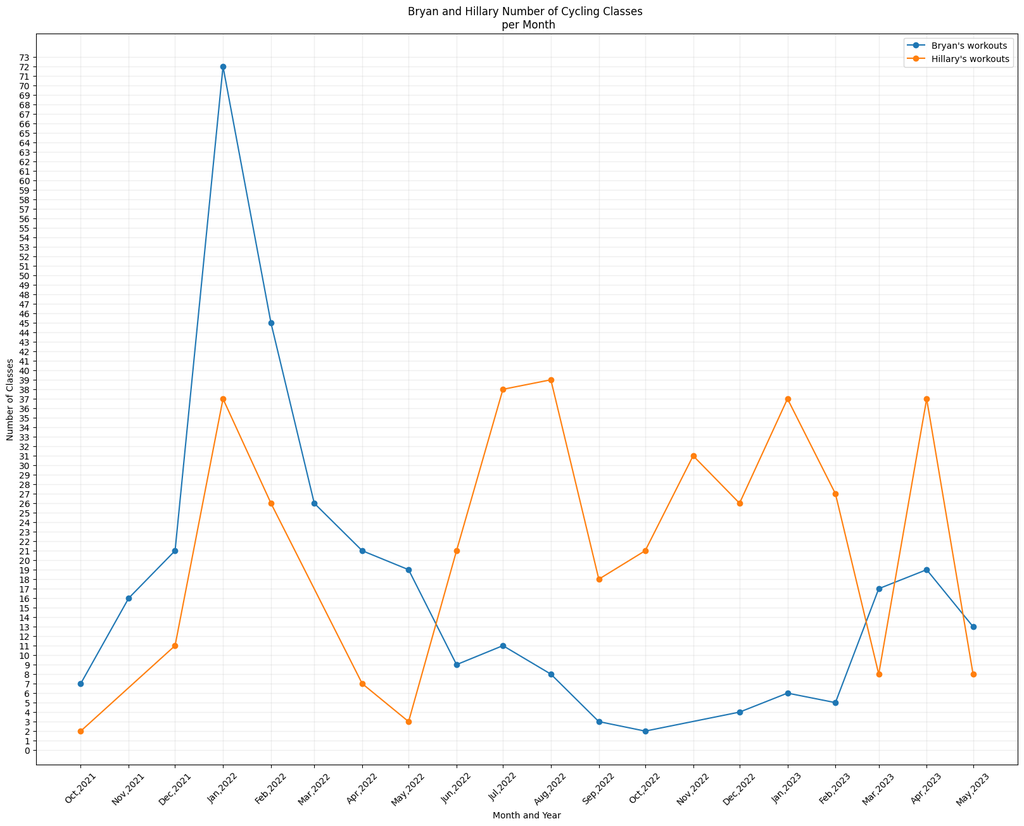

```python
df_by_month = df.groupby(['rider_name','month'], as_index= False).agg(month_count = ('day','count'))

bryan_workouts = df_by_month[df_by_month['rider_name'] == 'Bryan Kolano']
hillary_workouts = df_by_month[df_by_month['rider_name'] == 'Hillary Kolano']

fig, ax = plt.subplots(figsize=(10, 6))



ax.plot_date(data = bryan_workouts, x = 'month', y = 'month_count',ls = 'solid', label = "Bryan's workouts")
ax.plot_date(data = hillary_workouts, x = 'month', y = 'month_count',ls = 'solid', label = "Hillary's workouts")

#use these methods to set x-ticks to month, then format the month, the rotate the month
ax.xaxis.set_major_locator(mdates.MonthLocator())
ax.xaxis.set_major_formatter(mdates.DateFormatter('%b,%Y'))
ax.xaxis.set_tick_params(rotation = 45)

ax.yaxis.set_ticks(range(0,df_by_month['month_count'].max() + 2))

plt.title("Bryan and Hillary Number of Cycling Classes \n per Month")
plt.xlabel('Month and Year')
plt.ylabel('Number of Classes')
plt.legend(loc = 1)
ax.grid(True, linewidth = 1, alpha = .2 )
```

Looking at proportion of the classes we take, it's very evident I principally use Peloton for yoga and Hillary uses it for cycling. As mentioned before, I do most of my exercise at the gym, and use Peloton (particularly Peloton yoga) as a supplement.

Since Hillary's principal way of exercise is through Peloton, it makes sense that the majority of the classes she takes are cycling or strength.

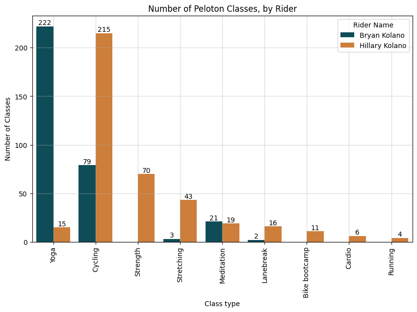

```python
class_summary = df.groupby(['rider_name','class_type'], as_index= False).agg(total = ('day','count')).sort_values(['total','rider_name'], ascending=[False, True])

plt.figure(figsize=(10,6))

ax = sns.barplot(data=class_summary, x="class_type", y="total", hue = 'rider_name',  palette= ['#025464','#E57C23'])

#Because the format of the class type is lower case with '_' to separate multiword labels, we need to change the x labels
#somewhat to make them look more presentable

#Grab current label indices and labels
locs, labels = plt.xticks()

#New list of labels to create
new_x_ticks = []

#Loop through current labels.  If there is a '_', remove it and capitalize word
#Otherwise, capitalize the word
for type in labels:
    if '_' in type.get_text():
        new_x_ticks.append(type.get_text().replace('_', ' ').capitalize())
    else:
        new_x_ticks.append(type.get_text().capitalize())



plt.title('Number of Peloton Classes, by Rider')
plt.ylabel("Number of Classes")
plt.xlabel('Class type')

#Apply the original tick locations with the new tick labels
plt.xticks(rotation = 90, ticks= locs, labels= new_x_ticks)
plt.legend(loc = 'upper right', title = "Rider Name")
plt.grid(True, linewidth = 1, alpha = .4)

#label each column with the actual number value
for i in ax.containers:
    ax.bar_label(i,)


plt.show()
```

Above, we looked at the absolute number of classes by class type, but let's take a look at the proportion of classes by rider.

```python
#group by rider and class type, finding total number of classes by person
summary_rider_class = df.groupby(['rider_name','class_type']).agg(proportion = ('day','count'))

#Create new groupby whih only groups by rider
summary_rider = df.groupby('rider_name').agg(proportion = ('day','count'))

#divide the rider_class dataframe by the rider dataframe to get the overall proportion each rider has for each class type
proportions_by_rider = summary_rider_class.div(summary_rider, level=  'rider_name').reset_index()

#round the propoportion
proportions_by_rider['proportion'] = proportions_by_rider['proportion'].round(3)

#Now merge this new proportion dataframe to our original class summary dataframe
proportions_with_total = proportions_by_rider.merge(right = class_summary, how = 'left', left_on= ['rider_name','class_type'], right_on=['rider_name','class_type'])


proportions_with_total
```

[output not shown]

Using the proportion data above, we can create a unique visualization that plots of each side of the y-axis for each rider. The plot below takes the proportion data, by rider, and then plots it on either side of the y-axis. This creates a unique comparison to show how Hillary and I compare to each other for the proportion of classes taken.

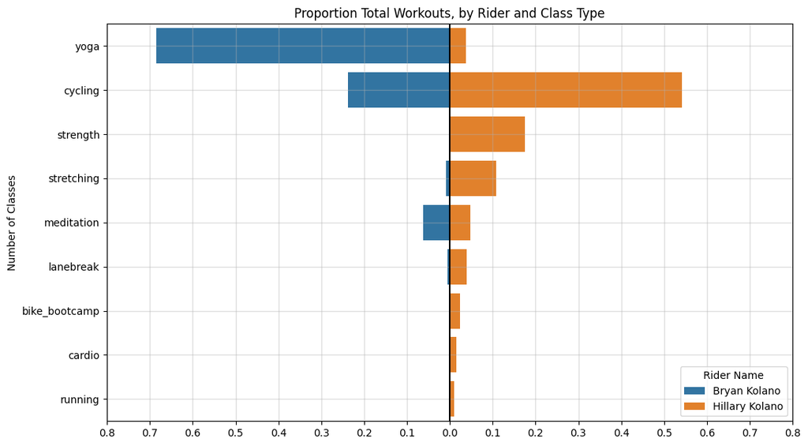

```python
plt.figure(figsize=(10,6))

#next to be able to create this interesting barplot, I need to manipulate the data a bit. Whereever the rider is Bryan, convert the workouts to negative.
df_proportions = proportions_with_total.copy()
df_proportions['proportion'] = df_proportions.apply(lambda x: x['proportion'] * -1 if x['rider_name'] == "Bryan Kolano" else x['proportion'], axis = 1)
#then sort by the total
df_proportions = df_proportions.sort_values('total', ascending= False).reset_index(drop = True)

sns.barplot(data = df_proportions, x = 'proportion', y = 'class_type',  hue = 'rider_name',  errorbar = None , dodge= False )
#draw a vertical line at 0
plt.axvline(x =0, ymin=0, ymax= 1, color = 'black')

#Need to manipulate the ticks on the left side of the graphic.  Even though they are negative, need to take the absolute value so the plot appears positive.
plt.xticks(np.arange(-.8, .9, step=0.1), labels= [ 0.8,0.7, 0.6, 0.5, 0.4,0.3, 0.2, 0.1, 0.0, 0.1, 0.2, 0.3, 0.4, 0.5, 0.6, 0.7, 0.8])
plt.title("Proportion Total Workouts, by Rider and Class Type")
plt.ylabel("Number of Classes")
plt.xlabel('')


plt.legend(loc = 'lower right', title = "Rider Name")
plt.grid(True, linewidth = 1, alpha = .4 )

plt.show()
```

#### 3. Cycling Analysis

When you take a cycling class on the Peloton bike, your bike will track total output of the ride based on length of the class, resistence of the bike, and cadence of pedal strokes. As such, we can use the output for additional analysis that is unique to cycling.

The section of code below grabs only cycling classes (and Lanebreak which is a special type of cycling) and get rid of the classes that might have started accidentally and have outputs of less than 1 Kilojoule. Additionally, all warmup and cooldown classes of five or 10 minutes are dropped.

```python
#Grab all the cycling classes, and only those that have an output > 0 (some cycling classes must have been canceled and have a 0 Kj output)
df_rides_only = df[(df['class_type'] == 'cycling') | (df['class_type'] == 'lanebreak')]
df_rides_only = df_rides_only[df_rides_only['total_output_kj'] > 1 ]

#get rid of all the 5 and 10 minute warm ups
df_no_warm_cool = df_rides_only[df_rides_only['length_min'] > 10]
```

As part of the cycling analysis Hillary wanted me to do, I decided to compare our total output by class length using a box plot. In the plot below, we can see that I have exactly one 15 minute class and one 45 minute class, so there is not much to analyze. All other cycling classes are either 20 or 30 minutes. Also, with my cycling, my ride output is pretty consistent. The first and third quartile (inner quartile range (IQR)) are closely spaced to the median for my rides. Compare this to Hillary's rides for 20 and 30 minutes. Her IQR is pretty wide. She often tells me that some days she is really feeling a ride, and hence has a great output. Other days, she tells me she really struggled to get into the ride and get a solid output.

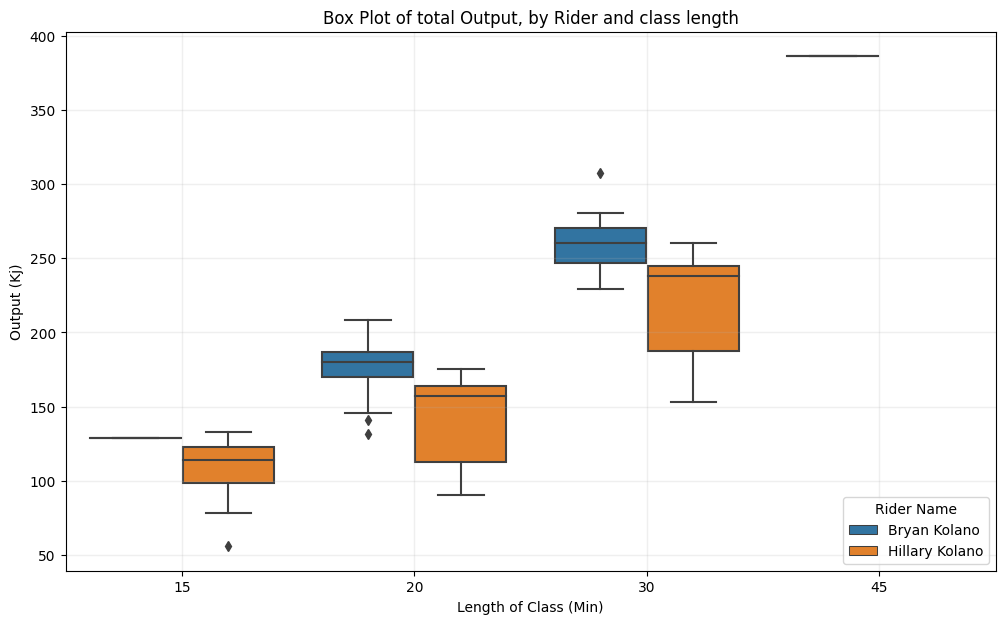

```python
plt.figure(figsize=(10,6))

#Box plot to show average total output, by rider, by class length
sns.boxplot(data = df_no_warm_cool, x = 'length_min', y = 'total_output_kj', hue = 'rider_name')
plt.legend(loc = 'lower right', title = "Rider Name")
plt.grid(True, linewidth = 1, alpha = .2 )
plt.title("Box Plot of total Output, by Rider and class length")
plt.ylabel("Output (Kj)")
plt.xlabel('Length of Class (Min)')


plt.show()
```

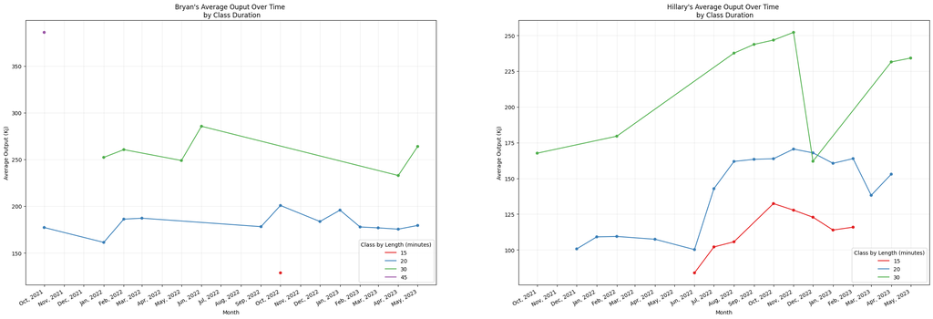

```python
#Mute chained assignment warning
pd.options.mode.chained_assignment = None



monthly_output= df_no_warm_cool.groupby(['rider_name','month','length_min'], as_index= False).agg(avg_output = ('total_output_kj','mean'))

fig, axs = plt.subplots(nrows = 1, ncols=2, figsize=(30,10))

names = ['Bryan Kolano','Hillary Kolano']

#Loops through riders and each axis
for name, ax in zip(names, axs.ravel()):

    current_data = monthly_output[monthly_output['rider_name'] == name]

    #Need to get the number of different class length
    class_length = sorted(current_data['length_min'].unique())
    #We take the number of unique class lengths, and apply them to a  unique palette.
    # # This is necessary we different number of class lengths between Bryan and Hillary.
    #Bryan has four class lengths and Hillary has three.  If we try to set a color palette to only 3 or to 4,
    # we are going to have an error.  For example, if we choose 4 colors to match Bryan, Hillary's loop with through an error.
    #Therefore, we need a dynamic palette that changes the number of colors to return based on how many different class lengths there are.
    palette = dict(zip(class_length, sns.color_palette('Set1', n_colors= len(class_length))))


    sns.scatterplot(x = 'month', y= 'avg_output', hue = 'length_min',
                    palette=palette, data = current_data, legend = False, ax = ax)


    sns.lineplot(x = 'month', y= 'avg_output', hue = 'length_min',
                    palette=palette, data = current_data, ax = ax )


    #Use these axes methods to set the x ticks to monthly and then format and fit them
    ax.xaxis.set_major_locator(mdates.MonthLocator(interval=1))
    ax.xaxis.set_major_formatter(mdates.DateFormatter('%b, %Y'))
    plt.gcf().autofmt_xdate()

    ax.grid(True, linewidth = 1, alpha = .2 )

    ax.set_title(f"{name.split()[0]}'s Average Ouput Over Time \n by Class Duration")
    ax.set_xlabel('Month')
    ax.set_ylabel('Average Output (Kj)')
    ax.legend(title = "Class by Length (minutes)", loc = "lower right")
```

#### 4. Instructor Analysis

Finally, I told Hillary I wanted to do some quick instructor analysis to see which instructors push us the most for total output in a given class.

```python
#new dataframe to look at riders and instructors.  Grouping by rider, instructor and class length.
df_output_instructor = df_no_warm_cool.groupby(['rider_name','instructor','length_min'], as_index= False).agg(avg_output = ('total_output_kj','mean'),
                                                                                                             num_classes = ('instructor','count'))

df_output_instructor['instructor'] = df_output_instructor['instructor'].apply(lambda x: "Lanebreak" if x == "no instructor" else x)

df_output_instructor
```

|  | rider_name | instructor | length_min | avg_output | num_classes |
| --- | --- | --- | --- | --- | --- |
| 0 | Bryan Kolano | Alex Toussaint | 30 | 253.500000 | 1 |
| 1 | Bryan Kolano | Ally Love | 20 | 185.040000 | 5 |
| 2 | Bryan Kolano | Ally Love | 30 | 249.600000 | 2 |
| 3 | Bryan Kolano | Ben Alldis | 20 | 189.733333 | 3 |
| 4 | Bryan Kolano | Bradley Rose | 20 | 177.350000 | 4 |
| ... | ... | ... | ... | ... | ... |
| 68 | Hillary Kolano | Tunde Oyeneyin | 15 | 101.800000 | 1 |
| 69 | Hillary Kolano | Tunde Oyeneyin | 20 | 165.800000 | 1 |
| 70 | Hillary Kolano | Lanebreak | 15 | 128.100000 | 3 |
| 71 | Hillary Kolano | Lanebreak | 20 | 163.750000 | 6 |
| 72 | Hillary Kolano | Lanebreak | 30 | 242.300000 | 7 |

73 rows × 5 columns

With the data and associated visualizations below, I wanted to see if there were particular instructors that stood out in terms of how much they coached us to a particular total output. First, we are dealing with a very small dataset. Bryan only has 59 rides (that are not warmups/ cooldowns) and Hillary only has 151. It's difficult to discuss in detail descriptive statistics when there is not much to work with.

That said, we can still see a few trends in the data for each rider. We can use these visualizations as a guide for whether we want to take a class with an instructor who is going to push us more or one that will push us less. In the graphs below, in the x-axis labels, I have put the number of classes we have each taken with a particular instructor for a particular length of class. As an example, I have one 45-minute ride, with Jenn Sherman, and that single ride is represented next to her name on the x-axis in parentheses. In Hillary's graph, she has 17 20-minute rides with Robin Arzon.

For instructors where we only have one ride for each class length, we may or may not be able to draw conclusions from that. However, for 20-minutes rides, I have taken three with Ben Alldis and their average outputs have been higher than almost all of other 20-minute classes with other instructors. Therefore, perhaps I want to take a 20-minute class with Ben Alldis if I really want to exert myself. The same can be said for Hillary doing 20-minute Lanebreak classes.

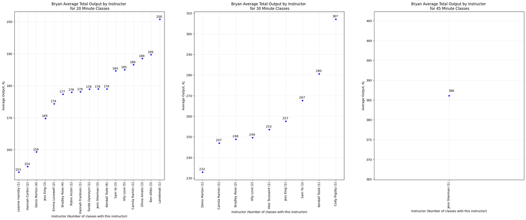

```python
#Starting with Bryan's data
bryan_data = df_output_instructor[df_output_instructor['rider_name'] == 'Bryan Kolano'].sort_values('avg_output')

#We are going to loop across these following lists together to create each graphic or to modify each graphic.
times = [20,30,45]

#These are x-axis and y-axis offsets for each graphic.  Given the x axis scale of each graph, we have to use different offsets for each graph, otherwise the offsets will look uneven in each graphic.
x_offset = [.4, .2, .0025]
y_offset = [.5, 1, 1]

#create subplots
fig, axs = plt.subplots(1,3, figsize = (30,10))

#loops across each graphic axis, for the offsets and class time
for x_offset, y_offset, time, ax in zip(x_offset, y_offset, times, axs.ravel()):

    current_data = bryan_data[bryan_data['length_min'] == time].reset_index(drop = True)

    #This was interesting.  I started with a scatter plot, but because we have a categorical x axis, we could not grab the text of the x axis ticks and change them.
    #I then switched to a strip plot.  This allows for categorical variables, so I cold grab and manipulate the x axis tick labels, but each time you plot points with
    #strip plot, it jitters them a little bit.  That isn't too much of an issue for the 20 and 30 minute plots.  But it was an issue for the single 45 minute plot.
    #Each time I tried to place a text label to the left of the point, the point would move to a different location each time I ran the code (hence the jittering)
    #I discovered that swarm plot would work for the effect I want.  This isn't a normal swarm plot, and doesn't look like a swarm, because there is only one value per x value,
    # but it served the purpose to grab the categorical x axis tick labels.
    sns.swarmplot(data = current_data, x = 'instructor', y = 'avg_output', ax = ax, color = 'blue')

    #grab current x tick labels
    labels = [item.get_text() for item in ax.get_xticklabels()]

    #create list to hold new labels
    labels_plus_num_classes = []

    #Loop across each label and each class total value, append the two numbers together
    for label, num in zip(labels,current_data['num_classes']):
        labels_plus_num_classes.append(f"{label} ({num})")

    #set the new tick labels and rotate them
    ax.set_xticklabels(labels=labels_plus_num_classes)
    ax.xaxis.set_tick_params(rotation=90)

    ax.set_xlabel('Instructor (Number of classes with this instructor)')
    ax.set_ylabel('Average Output, Kj')
    ax.set_title(f"Bryan Average Total Output by Instructor \n for {time} Minute Classes")
    ax.grid(True, linewidth = 1, alpha = .2 )

    #Loop across the avg_output column (with each associated offset), and then label each point with appropriate offset
    for i, txt in enumerate(current_data['avg_output'].astype('int')):
        ax.annotate(txt, (i-x_offset, current_data.loc[i,'avg_output'] + y_offset))
```

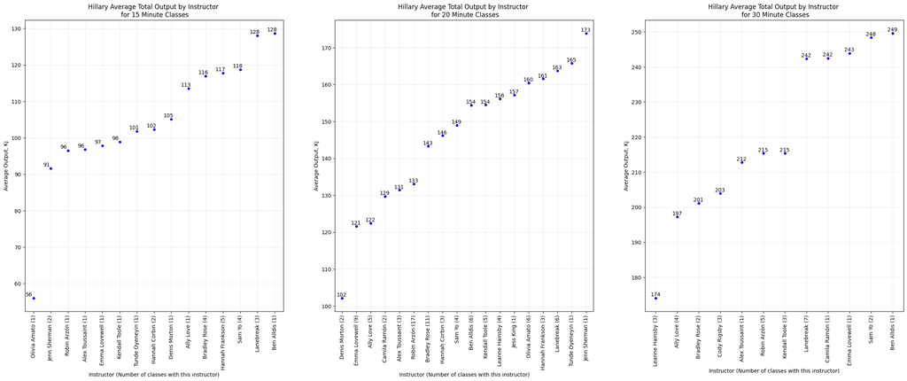

```python
#Do the same thing as above, but this time for Hillary
#I thought about doing one large loops to plot all Bryan and Hillary data at the same time (and make a 2 row by 3 column plot), but we have some different scales,
#so it was better to split up overall. For example, Hillary has some 15 minute rides and Bryan does not.  Bryan also has one 45 minute ride and Hillary does not.

hillary_data = df_output_instructor[df_output_instructor['rider_name'] == 'Hillary Kolano'].sort_values('avg_output')

times = [15,20,30]
x_offset = [.45, .4, .25]
y_offset = [.55, .4, .5]

fig, axs = plt.subplots(1,3, figsize = (30,10))

for x_offset, y_offset, time, ax in zip(x_offset, y_offset, times, axs.ravel()):

    current_data = hillary_data[hillary_data['length_min'] == time].reset_index(drop = True)

    #I prefer to use stripplot for this type of graph.  Since Hillary doesn't have any graphs that have only one data point,
    # it doesn't jitter the points enough to make a difference.  So I used swarmplot as a workaround for min
    # and I used my preference, stripplot, to plot Hillary's
    sns.stripplot(data = current_data, x = 'instructor', y = 'avg_output', ax = ax, color = 'blue')

    labels = [item.get_text() for item in ax.get_xticklabels()]


    labels_plus_num_classes = []

    for label, num in zip(labels,current_data['num_classes']):
        labels_plus_num_classes.append(f"{label} ({num})")

    ax.set_xticklabels(labels=labels_plus_num_classes)
    ax.xaxis.set_tick_params(rotation=90)
    ax.set_title(f"Hillary Average Total Output by Instructor \n for {time} Minute Classes")
    ax.set_xlabel('Instructor (Number of classes with this instructor)')
    ax.set_ylabel('Average Output, Kj')
    ax.grid(True, linewidth = 1, alpha = .2 )


    for i, txt in enumerate(current_data['avg_output'].astype('int')):
        ax.annotate(txt, (i-x_offset, current_data.loc[i,'avg_output'] + y_offset))
```

#### 4. Conclusion

This was a really fun project, from the data pipeline to the data analysis and visualization. If I have some time I can dedicate in the future, I'm going to do some feature engineering on the data and perform more analysis and visualizations. For example, I'd like to look at time of day and day of week for when we tend to take Peloton classes.

This project has given me motivation to continue to take Peloton classes. I've been "slacking" on classes somewhat as I've spent more time running outside as opposed to Peloton cycling and I've been doing regular stretching as opposed to yoga. I want to encourage my wife and myself to continue to do more Peloton classes. Sure, the health benefits are one thing, but the data is what I really want!!